# Sarath S_V01109792_SCMA632_Exam 2

```python
import os
os.chdir('/Users/sarathsabu/Desktop/SCMA EXAM 2')
print("Current Working Directory: ", os.getcwd())
```

```
Current Working Directory:  /Users/sarathsabu/Desktop/SCMA EXAM 2
```

```python
import pandas as pd
import numpy as np
import matplotlib.pyplot as plt
from sklearn.metrics import mean_squared_error, mean_absolute_error
from sklearn.preprocessing import MinMaxScaler
from statsmodels.tsa.statespace.sarimax import SARIMAX
from keras.models import Sequential
from keras.layers import Dense, LSTM
import math
```

```python
# Load the data
df = pd.read_excel('CMO-Historical-Data-Monthly.xlsx', sheet_name="Monthly Prices", skiprows=6)

# Rename the first column to "Date"
df.rename(columns={df.columns[0]: 'Date'}, inplace=True)

# Convert the Date column to datetime format
def parse_date(date_str):
    year, month = date_str[:4], date_str[5:7]
    return pd.to_datetime(f'{year}-{month}-01')

df['Date'] = df['Date'].apply(parse_date)

# Display the structure of the dataframe
print(df.info())
```

```
<class 'pandas.core.frame.DataFrame'>
RangeIndex: 774 entries, 0 to 773
Data columns (total 72 columns):
 #   Column         Non-Null Count  Dtype
---  ------         --------------  -----
 0   Date           774 non-null    datetime64[ns]
 1   CRUDE_PETRO    774 non-null    float64
 2   CRUDE_BRENT    774 non-null    float64
 3   CRUDE_DUBAI    774 non-null    float64
 4   CRUDE_WTI      774 non-null    object
 5   COAL_AUS       774 non-null    object
 6   COAL_SAFRICA   774 non-null    object
 7   NGAS_US        774 non-null    float64
 8   NGAS_EUR       774 non-null    float64
 9   NGAS_JP        774 non-null    object
```

[output cut: 65 more lines]

```python
# Get the column numbers for each column
column_numbers = {col: idx for idx, col in enumerate(df.columns)}

# Select relevant columns
commodity = df.iloc[:, [0, 69]]

# Clean column names
commodity.columns = commodity.columns.str.lower().str.replace(' ', '_')

# Display the structure of the commodity dataframe
print(commodity.info())
```

```
<class 'pandas.core.frame.DataFrame'>
RangeIndex: 774 entries, 0 to 773
Data columns (total 2 columns):
 #   Column  Non-Null Count  Dtype
---  ------  --------------  -----
 0   date    774 non-null    datetime64[ns]
 1   gold    774 non-null    float64
dtypes: datetime64[ns](1), float64(1)
memory usage: 12.2 KB
None
```

```python
commodity.head()
```

|  | date | gold |
| --- | --- | --- |
| 0 | 1960-01-01 | 35.27 |
| 1 | 1960-02-01 | 35.27 |
| 2 | 1960-03-01 | 35.27 |
| 3 | 1960-04-01 | 35.27 |
| 4 | 1960-05-01 | 35.27 |

```python
# Save the daily data to a new CSV file
commodity.to_csv('gold_data.csv')
```

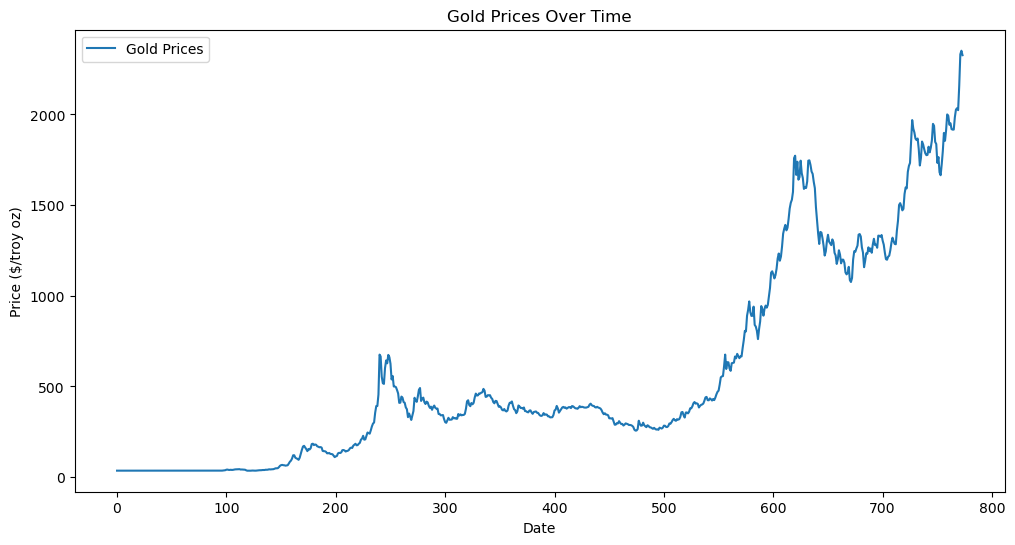

```python
# Plot the data
plt.figure(figsize=(12, 6))
plt.plot(commodity.index, commodity['gold'], label='Gold Prices')
plt.title('Gold Prices Over Time')
plt.xlabel('Date')
plt.ylabel('Price ($/troy oz)')
plt.legend()
plt.show()
```

#### The plot of gold prices over time shows a clear historical trend with several key phases. Initially, gold prices remain stable and low, reflecting minimal market fluctuations. Around the 200th index mark, there is a significant spike, indicating a sharp increase in demand or economic conditions driving up prices. Following this, the prices exhibit fluctuations with peaks and troughs, signifying periods of market volatility. A notable upward trend occurs around the 500th index mark, likely due to economic crises or global events increasing gold’s value. In the most recent data, gold prices reach their highest levels, indicating a sustained increase in value, possibly as a response to economic uncertainties. This overall upward trend underscores gold’s role as a safe-haven asset during turbulent economic times.

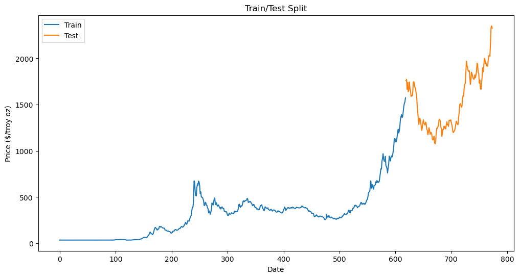

```python
# Assuming a larger dataset, split into train and test sets
train_size = int(len(commodity) * 0.8)
train, test = commodity[:train_size], commodity[train_size:]

# Plot the train and test sets
plt.figure(figsize=(12, 6))
plt.plot(train.index, train['gold'], label='Train')
plt.plot(test.index, test['gold'], label='Test')
plt.title('Train/Test Split')
plt.xlabel('Date')
plt.ylabel('Price ($/troy oz)')
plt.legend()
plt.show()
```

#### The plot of the train/test split for gold prices provides a clear visualization of how the dataset is divided for modeling. The blue line represents the training set, covering the initial 80% of the data, while the orange line represents the test set, comprising the remaining 20%. The training data shows the historical fluctuations and trends in gold prices up to the 600th index mark, including periods of stability, significant spikes, and volatility. The test data continues from this point, capturing the most recent price movements, which show a sharp upward trend, indicating an increasing value of gold. This division allows for the model to be trained on historical data and tested on more recent data to evaluate its predictive performance. The clear distinction between the training and test sets ensures that the model’s ability to generalize to new, unseen data can be effectively assessed, which is critical for accurate forecasting.